# Non-Diagonal Case

## 4.1 The output from the fit

The final object has many components

```r
names(demo.fit)
```

```
#>  [1] "n.chains"           "n.iter"             "n.burnin"
#>  [4] "n.thin"             "n.keep"             "n.sims"
#>  [7] "sims.array"         "sims.list"          "sims.matrix"
#> [10] "summary"            "mean"               "sd"
#> [13] "median"             "root.short"         "long.short"
#> [16] "dimension.short"    "indexes.short"      "last.values"
#> [19] "program"            "model.file"         "isDIC"
#> [22] "DICbyR"             "pD"                 "DIC"
#> [25] "model"              "parameters.to.save" "plots"
#> [28] "runTime"            "report"             "data"
```

The *plots* sub-object contains many plots:

```r
names(demo.fit$plots)
```

```
#> [1] "plot.init"         "fit.plot"          "logitP.plot"
#> [4] "acf.Utot.plot"     "post.UNtot.plot"   "musdLogTTt"
#> [7] "gof.plot"          "trace.logitP.plot" "trace.logU.plot"
```

In particular, it contains plots of the initial spline fit (*init.plot*), the final fitted spline (*fit.plot*), the estimated capture probabilities (on the logit scale) (*logitP.plot*), plots of the distribution of the posterior sample for the total unmarked and marked fish (*post.UNtot.plot*) and model diagnostic plots (goodness of fit (*gof.plot*), trace (*trace…plot*), and autocorrelation plots (*act.Utot.plot*).

These plots are all created using the $ggplot2$ packages, so the user can modify the plot (e.g. change titles etc).

The $BTSPAS$ program also creates a report, which includes information about the data used in the fitting, the pooled- and stratified-Petersen estimates, a test for pooling, and summaries of the posterior. Only the first few lines are shown below:

```r
head(demo.fit$report)
```

[output not shown]

Here is the fitted spline curve to the number of unmarked fish available in each recovery sample

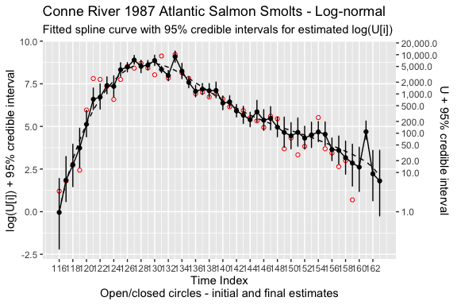

Fitted spline curve

```r
demo.fit$plots$fit.plot
```

The distribution of the posterior sample for the total number unmarked and total abundance is available:

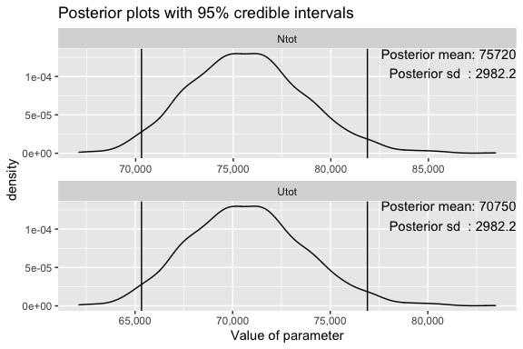

Distribution of posterior samples

```r
demo.fit$plots$post.UNtot.plot
```

A plot of the $logit(P)$ is

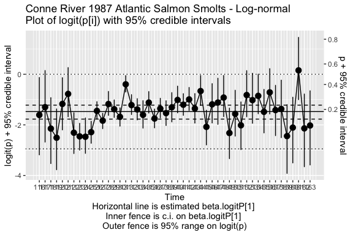

Estimates of logit(p)

```r
demo.fit$plots$logitP.plot
```

In cases where there is little information, $BTSPAS$ has shared information based on the distribution of catchability in the other strata.

A summary of the posterior for each parameter is also available. In particular, here are the summary statistics on the posterior sample for the total number unmarked and total abundance:

```r
demo.fit$summary[ row.names(demo.fit$summary) %in% c("Ntot","Utot"),]
```

```
#>          mean       sd     2.5%      25%     50%     75%    97.5%     Rhat n.eff
#> Ntot 75719.74 2982.231 70300.37 73627.25 75617.5 77619.5 81873.02 1.002045  1500
#> Utot 70749.74 2982.231 65330.37 68657.25 70647.5 72649.5 76903.02 1.002028  1500
```

This also includes the Rubin-Brooks-Gelman statistic ($Rhat$) on mixing of the chains and the effective sample size of the posterior (after accounting for autocorrelation).

The estimated total abundance from $BTSPAS$ is 75,720 (SD 2,982 ) fish.

The model has a “base” log-normal distribution for the travel times between the release and recovery strata. The summary of the posterior distribution of its parameters for the log(travel time) are:

```r
round(demo.fit$summary[ row.names(demo.fit$summary) %in% c("baseMu","baseSd"),],3)
```

```
#>         mean    sd  2.5%   25%   50%   75% 97.5%  Rhat n.eff
#> baseMu 0.684 0.052 0.584 0.651 0.683 0.718 0.787 1.001  1500
#> baseSd 0.281 0.020 0.242 0.267 0.280 0.294 0.321 1.000  1500
```

Each release stratum is allowed to have a travel time distribution that differ from this base travel time distribution, by allowing the individual release stratum parameters to be sampled from a distribution around the above vales. Posterior samples represent the mean and standard deviation of the log(travel time) between the release and recovery strata. Here are the results for the first 5 strata:

```r
round(demo.fit$summary[ grepl("muLogTT", row.names(demo.fit$summary)),][1:5,],3)
```

```
#>             mean    sd  2.5%   25%   50%   75% 97.5%  Rhat n.eff
#> muLogTT[1] 1.201 0.205 0.774 1.072 1.216 1.340 1.565 1.004   880
#> muLogTT[2] 0.682 0.303 0.087 0.484 0.676 0.887 1.277 1.003   620
#> muLogTT[3] 0.618 0.307 0.060 0.411 0.596 0.808 1.269 1.000  1500
#> muLogTT[4] 1.116 0.151 0.787 1.030 1.131 1.220 1.379 1.003  1500
#> muLogTT[5] 1.213 0.106 1.001 1.145 1.211 1.283 1.418 1.001  1400
```

```r
round(demo.fit$summary[ grepl("sdLogTT", row.names(demo.fit$summary)),][1:5,],3)
```

```
#>             mean    sd  2.5%   25%   50%   75% 97.5%  Rhat n.eff
#> sdLogTT[1] 0.300 0.100 0.143 0.231 0.288 0.352 0.532 1.000  1500
#> sdLogTT[2] 0.298 0.099 0.148 0.228 0.283 0.346 0.545 1.000  1500
#> sdLogTT[3] 0.290 0.092 0.151 0.223 0.278 0.346 0.509 1.001  1500
#> sdLogTT[4] 0.292 0.080 0.169 0.236 0.279 0.339 0.478 1.001  1500
#> sdLogTT[5] 0.292 0.059 0.202 0.250 0.284 0.323 0.442 1.000  1500
```

It is also possible to see the probability of moving from release stratum $i$ to recovery stratum $j$ by looking at the $Theta[i,j]$ values. Here are the transition probabilities for the first release stratum:

```r
round(demo.fit$summary[ grepl("Theta[1,", row.names(demo.fit$summary),fixed=TRUE),][1:10,],3)
```

```
#>              mean    sd  2.5%   25%   50%   75% 97.5%  Rhat n.eff
#> Theta[1,1]  0.005 0.021 0.000 0.000 0.000 0.001 0.056 1.004  1500
#> Theta[1,2]  0.084 0.109 0.000 0.004 0.034 0.127 0.371 1.002  1500
#> Theta[1,3]  0.268 0.143 0.009 0.154 0.281 0.378 0.518 1.001  1500
#> Theta[1,4]  0.330 0.117 0.118 0.252 0.325 0.402 0.575 1.004  1500
#> Theta[1,5]  0.196 0.111 0.032 0.110 0.179 0.265 0.435 1.003   910
#> Theta[1,6]  0.075 0.064 0.004 0.027 0.058 0.103 0.236 1.001  1500
#> Theta[1,7]  0.026 0.031 0.000 0.005 0.016 0.035 0.114 1.004  1500
#> Theta[1,8]  0.010 0.015 0.000 0.001 0.004 0.012 0.054 1.008  1500
#> Theta[1,9]  0.004 0.008 0.000 0.000 0.001 0.004 0.027 1.011  1500
#> Theta[1,10] 0.002 0.004 0.000 0.000 0.000 0.001 0.013 1.004  1500
```

The probabilities should sum to 1 for each release group.

Samples from the posterior are also included in the *sims.matrix*, *sims.array* and *sims.list* elements of the results object.

It is always important to do model assessment before accepting the results from the model fit. Please contact me for details on how to interpret the goodness of fit, trace, and autocorrelation plots.